# Understanding Flight Delays in America: A Data-Driven Review of 2019–2020

Sofia Posey

2025-11-20

## Purpose

The purpose of this project is to examine patterns of flight delays in the U.S. air travel system using 2019–2020 data from the Department of Transportation (via Kaggle). Rather than simply counting how many flights were late, the analysis focuses on how delays vary across airlines, states, and causes (carrier, NAS, weather, late aircraft, and security). By breaking delays down in this way, the project aims to distinguish problems that are largely systemic, such as traffic congestion in the NAS, from those that are more closely tied to individual carriers’ operations and scheduling decisions.

More specifically, the project seeks to answer the following questions:

- Which airlines and states in this sample experience the highest totals of delayed flights and delay minutes?
- How strongly are delays related to traffic volume (number of flights) at the state or airline level?
- For states of interest, what proportion of total delay minutes is explained by carrier issues, late aircraft, NAS constraints, weather, and security?
- How do delay patterns change between 2019 and 2020, a period with major disruptions to air travel?

Answering these questions provides an initial evidence base for understanding where delays are most concentrated and which types of causes contribute the most to nationwide disruption.

# Introduction

Flight delays commonly happen through the U.S. air travel system: they frustrate travelers, disrupt airline schedules and crew rotations, and congest airport gates, all of this problems add real costs to carriers and airports. Studying delay causes, like carrier, NAS, weather, late-arriving aircraft, security, patterns over time, airport locations, and carriers, helps identify which problems are systemic (such as air traffic control or airport congestion) versus operator-specific (such as airline scheduling). This evidence base supports better planning by airlines and airports, and informs policy aimed at reducing nationwide disruptions (Bureau of Transportation Statistics, 2021).

In the U.S., a large proportion of delays is attributed to the NAS. The NAS refers to the nationwide network of airspace, this variable covers operations like air traffic control services, airport facilities, navigation equipment, procedures, and the people and technology that run them. Delays categorized as NAS include “non-extreme weather conditions, airport operations, heavy traffic volume, and air traffic control” (Bureau of Transportation Statistics, 2024). NAS related issues covers heavy traffic volume, airspace flow programs, or equipment outages. Also note that flights can be delayed even when an individual airline did everything right.This analysis explores why flights get delayed grouping data by airline, location, and terminal, all of this, based on data from the 2019–2020 U.S. internal flight records; the focus of this project is on spotting trends across carriers and hubs.

# Data

The original data used in this project comes from a Kaggle dataset. The author of that dataset reports that the underlying information was retrieved from the United States Department of Transportation.

```r
#Library
library(libr)
library(tidyverse)
library(ggplot2)
library(packcircles)
library(usmap)
library(ggrepel)
library(scales)
library(forcats)
```

### Data Loading

The original data set have 3351 rows by 21 columns.

```r
airlines <- read.csv("airline_delay.csv")
```

```r
dim(airlines)
```

```
[1] 3351   21
```

## Key Variables and Structure

# Cleaning

The cleaning process focused on retaining only complete, well-identified U.S. flight records and making the location information in a standardized format. First, all observations containing missing values fields were identified and removed. Next, the original airport descriptor, which combined city, state abbreviation, and airport name into a single text string, was divided into three separate variables representing city, state, and airport name by splitting on punctuation marks. Finally, state abbreviations were standardized to a consistent format, and observations were filtered so that only records associated with valid U.S. states and the District of Columbia were retained.

```r
#Identify NA values
airlines[is.na(airlines$arr_flights), ]
```

|  | year | month | carrier | carrier_name | airport | airport_name | arr_flights | arr_del15 | carrier_ct | weather_ct | nas_ct | security_ct | late_aircraft_ct | arr_cancelled | arr_diverted | arr_delay | carrier_delay | weather_delay | nas_delay | security_delay | late_aircraft_delay |
| --- | --- | --- | --- | --- | --- | --- | --- | --- | --- | --- | --- | --- | --- | --- | --- | --- | --- | --- | --- | --- | --- |
| 342 | 2020 | 12 | DL | Delta Air Lines Inc. | BIL | Billings, MT: Billings Logan International | NA | NA | NA | NA | NA | NA | NA | NA | NA | NA | NA | NA | NA | NA | NA |
| 350 | 2020 | 12 | DL | Delta Air Lines Inc. | CHA | Chattanooga, TN: Lovell Field | NA | NA | NA | NA | NA | NA | NA | NA | NA | NA | NA | NA | NA | NA | NA |
| 367 | 2020 | 12 | DL | Delta Air Lines Inc. | FAI | Fairbanks, AK: Fairbanks International | NA | NA | NA | NA | NA | NA | NA | NA | NA | NA | NA | NA | NA | NA | NA |
| 958 | 2020 | 12 | OO | SkyWest Airlines Inc. | BDL | Hartford, CT: Bradley International | NA | NA | NA | NA | NA | NA | NA | NA | NA | NA | NA | NA | NA | NA | NA |
| 1148 | 2020 | 12 | OO | SkyWest Airlines Inc. | PWM | Portland, ME: Portland International Jetport | NA | NA | NA | NA | NA | NA | NA | NA | NA | NA | NA | NA | NA | NA | NA |
| 1265 | 2020 | 12 | UA | United Air Lines Inc. | PNS | Pensacola, FL: Pensacola International | NA | NA | NA | NA | NA | NA | NA | NA | NA | NA | NA | NA | NA | NA | NA |
| 1285 | 2020 | 12 | UA | United Air Lines Inc. | STL | St. Louis, MO: St Louis Lambert International | NA | NA | NA | NA | NA | NA | NA | NA | NA | NA | NA | NA | NA | NA | NA |
| 2590 | 2019 | 12 | OO | SkyWest Airlines Inc. | MLB | Melbourne, FL: Melbourne International | NA | NA | NA | NA | NA | NA | NA | NA | NA | NA | NA | NA | NA | NA | NA |

```r
nona_airlines <- na.omit(airlines) #getting rid of NA rows

#getting City and State from Airport name
clean_airlines <- separate(
  nona_airlines,
  airport_name,
  c("city", "abbr", "airport_name"),
  ",\\s*|:\\s*"

)
```

```r
#keep only 51 states
valid <- c(state.abb, "DC")
clean_airlines <- clean_airlines %>%
  mutate(abbr = toupper(abbr)) %>%
  filter(abbr %in% valid)
```

### Final Data Dimensions

Based on the previous cleaning description. The final clean data frame has 3303 rows by 23 columns.

```r
dim(clean_airlines)
```

```
[1] 3303   23
```

# Dictionary

For this section, variable descriptions were obtained from the Kaggle documentation associated with this dataset. One exception is the variable arr_flights, which was not clearly defined in the original source. Based on documentation from the U.S. Department of Transportation, arr_flights is interpreted in this project as the number of “on-time” arriving flights recorded at each airport–carrier combination.

```r
#creatng a table dictionary with libr
airlines_dictionary <- dictionary(clean_airlines)
```

```r
#adding each variable description
airlines_dictionary$Description <- c(
  "Year data collected",
  "Month data collected",
  "Airline carrier",
  "Carrier name",
  "Airport code",
  "Airport's city",
  "Airport's state",
  "Name of the airport",
  "Number of on time flights arriving at airport",
  "Total Number of flights more than 15 minutes late",
  "Percent of flights delayed due to air carrier (e.g. no crew)",
  "Percent of flights due to weather",
  "Percent of flights delayed due to National Aviation System (e.g. heavy air traffic)",
  "Percent of flights canceled due to a security breach",
  "Percent of flights delayed as a result of another flight on the same aircraft delayed",
  "Number of cancelled flights",
  "Number of flights that were diverted",
  "Sum of Total time (minutes) of delayed flight",
  "Total time (minutes) of delay due to air carrier",
  "Total time (minutes) of delay due to inclement weather",
  "Total time (minutes) of delay due to National Aviation System",
  "Total time (minutes) of delay as a result of a security issue",
  "Total time (minutes) of delay flights as a result of a previous flight on the same airplane being late"
)
```

```r
#getting rid of null columns of the dictionary table
airlines_dictionary$Label <- NULL
airlines_dictionary$Format <- NULL
airlines_dictionary$Width <- NULL
airlines_dictionary$Justify <- NULL
airlines_dictionary$Name <- NULL
names(airlines_dictionary)[names(airlines_dictionary) == "Column"] <- "Variable"
```

```r
#printing dictionary table
airlines_dictionary
```

| Variable | Class | Description | Rows | NAs | MaxChar |
| --- | --- | --- | --- | --- | --- |
| year | integer | Year data collected | 3303 | 0 | 4 |
| month | integer | Month data collected | 3303 | 0 | 2 |
| carrier | character | Airline carrier | 3303 | 0 | 2 |
| carrier_name | character | Carrier name | 3303 | 0 | 23 |
| airport | character | Airport code | 3303 | 0 | 3 |
| city | character | Airport's city | 3303 | 0 | 30 |
| abbr | character | Airport's state | 3303 | 0 | 2 |
| airport_name | character | Name of the airport | 3303 | 0 | 52 |
| arr_flights | integer | Number of on time flights arriving at airport | 3303 | 0 | 5 |
| arr_del15 | integer | Total Number of flights more than 15 minutes late | 3303 | 0 | 4 |

[output cut: 13 more lines]

# Exploratory Data Analysis

## Summary Statistics

```r
summary(clean_airlines)
```

```
      year          month      carrier          carrier_name         airport              city               abbr
 Min.   :2019   Min.   :12   Length:3303        Length:3303        Length:3303        Length:3303        Length:3303
 1st Qu.:2019   1st Qu.:12   Class :character   Class :character   Class :character   Class :character   Class :character
 Median :2019   Median :12   Mode  :character   Mode  :character   Mode  :character   Mode  :character   Mode  :character
 Mean   :2019   Mean   :12
 3rd Qu.:2020   3rd Qu.:12
 Max.   :2020   Max.   :12
 airport_name        arr_flights        arr_del15         carrier_ct        weather_ct         nas_ct         security_ct
 Length:3303        Min.   :    1.0   Min.   :   0.00   Min.   :  0.000   Min.   : 0.000   Min.   :   0.00   Min.   : 0.000
 Class :character   1st Qu.:   35.0   1st Qu.:   5.00   1st Qu.:  1.475   1st Qu.: 0.000   1st Qu.:   0.82   1st Qu.: 0.000
 Mode  :character   Median :   83.0   Median :  12.00   Median :  4.750   Median : 0.060   Median :   2.98   Median : 0.000
                    Mean   :  300.0   Mean   :  51.23   Mean   : 16.085   Mean   : 1.453   Mean   :  16.28   Mean   : 0.138
                    3rd Qu.:  193.5   3rd Qu.:  33.00   3rd Qu.: 12.245   3rd Qu.: 1.020   3rd Qu.:   8.87   3rd Qu.: 0.000
                    Max.   :19713.0   Max.   :2289.00   Max.   :697.000   Max.   :89.420   Max.   :1039.54   Max.   :17.310
 late_aircraft_ct arr_cancelled      arr_diverted       arr_delay        carrier_delay   weather_delay       nas_delay
 Min.   :  0.00   Min.   :  0.000   Min.   : 0.0000   Min.   :     0.0   Min.   :    0   Min.   :    0.0   Min.   :    0.0
 1st Qu.:  0.92   1st Qu.:  0.000   1st Qu.: 0.0000   1st Qu.:   231.5   1st Qu.:   68   1st Qu.:    0.0   1st Qu.:   21.0
 Median :  3.29   Median :  0.000   Median : 0.0000   Median :   748.0   Median :  271   Median :    3.0   Median :  106.0
 Mean   : 17.28   Mean   :  2.909   Mean   : 0.5798   Mean   :  3351.1   Mean   : 1148   Mean   :  179.1   Mean   :  753.8
 3rd Qu.: 10.26   3rd Qu.:  2.000   3rd Qu.: 0.0000   3rd Qu.:  2100.5   3rd Qu.:  836   3rd Qu.:   82.0   3rd Qu.:  361.5
 Max.   :819.66   Max.   :224.000   Max.   :42.0000   Max.   :160383.0   Max.   :55215   Max.   :14219.0   Max.   :82064.0
 security_delay    late_aircraft_delay
 Min.   :  0.000   Min.   :    0
 1st Qu.:  0.000   1st Qu.:   32
 Median :  0.000   Median :  207
 Mean   :  5.409   Mean   : 1264
 3rd Qu.:  0.000   3rd Qu.:  725
 Max.   :553.000   Max.   :75179
```

# Summary Statistics by State

In order to better visualize this numerical data. The following table reports a summary statistics for arrival delay minutes by state for the 2019–2020 period, including the mean, standard deviation, minimum, and maximum delay. The state with the longest average total delay is New Jersey (NJ), with 14249 minutes of delayed flights. While the shortest average delay state is Montana (MT) with a an average of 586 minutes in delays.

```r
stat_airlines <- clean_airlines %>%
  summarise(
    mean_airline = mean(arr_delay),
    sd_airline = sd(arr_delay),
    min_airline = min(arr_delay),
    max_airline = max(arr_delay),
    .by = abbr
  )
arrange(stat_airlines, mean_airline)
```

| abbr | mean_airline | sd_airline | min_airline | max_airline |
| --- | --- | --- | --- | --- |
| MT | 586.4561 | 667.0226 | 0 | 2921 |
| KS | 663.1290 | 889.4964 | 0 | 3633 |
| WV | 745.6667 | 1197.6312 | 0 | 3788 |
| ME | 746.7241 | 919.7333 | 0 | 3263 |
| AR | 789.0000 | 990.7948 | 0 | 4435 |
| WY | 793.8182 | 652.0914 | 19 | 2638 |
| SD | 825.3611 | 1074.3270 | 0 | 3807 |
| IA | 860.3191 | 1005.6251 | 0 | 4321 |
| MS | 917.8966 | 1414.2052 | 0 | 6662 |
| NE | 970.3953 | 1406.5668 | 0 | 6631 |

[output cut: 40 more lines]

### Box plot Distribution of delayed time by State

To better compare states with both typical and extreme delays, a logarithmic scale was applied to the delay variable. This compresses the distance to very large values and makes the overall distribution easier to see. The boxplot of flight delay minutes by state (top 10, log scale) highlights the middle 50% of the data while reducing the visual influence of extreme outliers.

```r
df_box <- clean_airlines %>%
  mutate(total_delay = pmax(
    carrier_delay + weather_delay + nas_delay + security_delay + late_aircraft_delay,
    0
  ))
```

```r
top_states <- df_box %>%
  group_by(abbr) %>% summarise(med = median(total_delay, na.rm = TRUE)) %>%
  slice_max(med, n = 10, with_ties = FALSE) %>% pull(abbr)
```

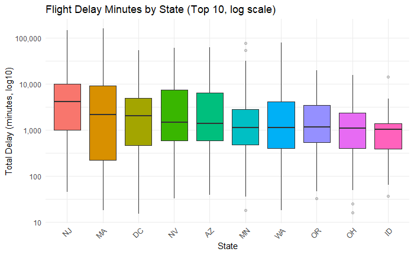

```r
top_box <- df_box %>%
  filter(abbr %in% top_states) %>%
  mutate(abbr = forcats::fct_reorder(abbr, total_delay, .fun = median, .desc = TRUE)) %>%
  ggplot(aes(x = abbr, y = total_delay, fill = abbr)) +
  geom_boxplot(outlier.alpha = 0.2) +
  scale_y_log10(labels = scales::comma) +
  labs(x = "State", y = "Total Delay (minutes, log10)",
       title = "Flight Delay Minutes by State (Top 10, log scale)") +
  theme_minimal() + theme(legend.position = "none",
                          axis.text.x = element_text(angle = 45, hjust = 1))
top_box
```

The second boxplot shows the 10 states with the fewest flight records. As before, each colored box represents the distribution of total delay minutes per flight on a log scale. Where West Virginia (WV), Maine (ME), Mississippi (MS) and Vermont (VT) have especially low medians and relatively compact boxes, suggesting smaller and more consistently low delay totals. Because the y-axis is on a log10 scale, even small vertical differences could represent large percentages changes in total delay. However, there is still some overlap between the upper end of the “best” states and the lower end of the “worst” states, so ranking by state is not absolute.

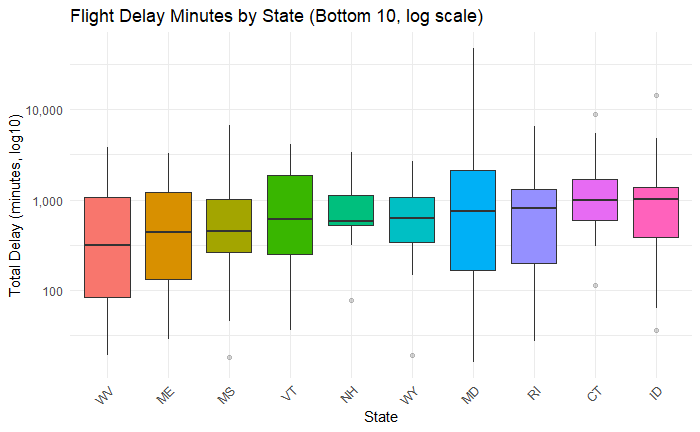

```r
#Bottom 10 graph
df_box <- clean_airlines %>%
  mutate(total_delay = pmax(
    carrier_delay + weather_delay + nas_delay + security_delay + late_aircraft_delay,
    0
  ))


bottom_states <- df_box %>%
  count(abbr, sort = TRUE) %>%
  slice_min(n, n = 10, with_ties = FALSE) %>%
  pull(abbr)


df_box %>%
  filter(abbr %in% bottom_states) %>%
  mutate(abbr = fct_reorder(abbr, total_delay, .fun = median)) %>%
  ggplot(aes(x = abbr, y = total_delay, fill = abbr)) +
  geom_boxplot(outlier.alpha = 0.2) +
  scale_y_log10(labels = comma) +
  labs(
    title = "Flight Delay Minutes by State (Bottom 10, log scale)",
    x = "State",
    y = "Total Delay (minutes, log10)"
  ) +
  theme_minimal() +
  theme(legend.position = "none",
        axis.text.x = element_text(angle = 45, hjust = 1))
```

## Airlines Tables

For further understanding about the data in this project is relevant to present some information about the carriers of this data set. The first table works as a reference for the commercial names of the airlines and their abbreviations used throughout this analysis. In total, the dataset includes 17 airlines operating within the United States.

```r
airline_code <- clean_airlines %>%
  distinct(carrier_name, carrier) %>%
  arrange(carrier_name, carrier)

airline_code
```

| carrier_name | carrier |
| --- | --- |
| Alaska Airlines Inc. | AS |
| Allegiant Air | G4 |
| American Airlines Inc. | AA |
| Delta Air Lines Inc. | DL |
| Endeavor Air Inc. | 9E |
| Envoy Air | MQ |
| ExpressJet Airlines LLC | EV |
| Frontier Airlines Inc. | F9 |
| Hawaiian Airlines Inc. | HA |
| JetBlue Airways | B6 |

[output cut: 7 more lines]

```r
airlines_count <- table(clean_airlines$carrier_name)
airlines_count
```

```
   Alaska Airlines Inc.           Allegiant Air  American Airlines Inc.    Delta Air Lines Inc.       Endeavor Air Inc.
                    144                     239                     193                     246                     226
              Envoy Air ExpressJet Airlines LLC  Frontier Airlines Inc.  Hawaiian Airlines Inc.         JetBlue Airways
                    285                     106                     182                      36                     114
     Mesa Airlines Inc.       PSA Airlines Inc.        Republic Airline   SkyWest Airlines Inc.  Southwest Airlines Co.
                    219                     187                     196                     479                     179
       Spirit Air Lines   United Air Lines Inc.
                     90                     182
```

## Airline Circle Packing (2019–2020)

This graph shows a circle packing visualization of the number of flights recorded for each airline in 2019–2020. In it, each circle represents one airline, and the area of the circle is proportional to the total number of flights in the dataset. Colors distinguish individual carriers, and the two-letter abbreviations are shown inside each circle, with the full names listed in the legend.

Comparing this figure to the previous summary table, we can see that Hawaiian Airlines Inc. has the smallest circle, confirming that it operated the fewest flights in this sample. In contrast, SkyWest Airlines Inc. has the largest circle, reflecting the highest total number of flights. This visualization is useful for quickly identifying airlines of particular interest for the rest of the report, since it highlights which carriers account for most of the observed flight activity and delays.

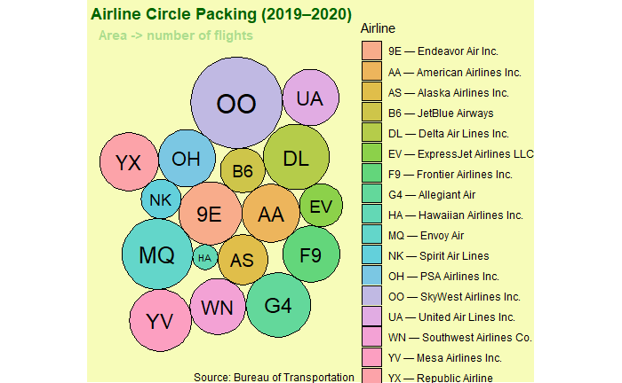

```r
#Creating Circle Stack Graph of Airlines
counts <- clean_airlines %>%
  count(carrier, name = "value") %>%
  left_join(airline_code, by = "carrier")


packing <- circleProgressiveLayout(counts$value, sizetype = "area")


dat <- counts %>%
  mutate(id = dplyr::row_number()) %>%
  bind_cols(packing)


dat_vertices <- circleLayoutVertices(packing, npoints = 50) %>%
  left_join(dat %>% select(id, carrier), by = "id")

#  Legend labels:
labs <- setNames(paste(dat$carrier, "—", dat$carrier_name), dat$carrier)

# Plot
ggplot() +
  geom_polygon(
    data = dat_vertices,
    aes(x, y, group = id, fill = carrier),
    colour = "black", alpha = 0.6
  ) +
  geom_text(
    data = dat,
    aes(x, y, label = carrier, size = value),
    color = "black"
  ) +
  scale_size_continuous(range = c(3, 8), guide = "none") +
  scale_fill_discrete(name = "Airline", labels = labs) +
  theme_void() +
  labs(
    title = "Airline Circle Packing (2019–2020)",
    subtitle = "Area -> number of flights",
    caption = "Source: Bureau of Transportation"
  ) +
  theme(
    legend.position = "right",
    plot.title = element_text(face = "bold", color = "darkgreen", hjust = 0.5),
    plot.subtitle = element_text(face = "bold", color = "#addd8e", hjust = 0.1),
    panel.background = element_rect(fill = "#f7fcb9"),
    plot.background = element_rect(fill = "#f7fcb9")
  ) +
  coord_equal()
```

## Flights by State

This table reports the number of flight records per state in the 2019–2020 sample. The most frequently represented states are Texas, California, Florida, and New York, each with more than 150 observations. At the other end of the distribution, West Virginia, Vermont, and New Hampshire appear the least often, with fewer than 20 recorded flights. These counts reflect how often each state appears in this data set, not necessarily total real-world traffic, but they highlight where most of the analyzed activity is concentrated.

```r
table(clean_airlines$abbr)
```

```
 AK  AL  AR  AZ  CA  CO  CT  DC  FL  GA  HI  IA  ID  IL  IN  KS  KY  LA  MA  MD  ME  MI  MN  MO  MS  MT  NC  ND  NE  NH  NJ  NM  NV  NY  OH
 39  52  47  55 247  95  26  49 267  66  52  47  29  76  54  31  40  78  30  29  29 109  47  72  29  57 116  42  43  12  29  32  43 165 111
 OK  OR  PA  RI  SC  SD  TN  TX  UT  VA  VT  WA  WI  WV  WY
 52  39 102  21  78  36  95 251  33  77  16  45  76  15  22
```

## Delays by Carrier

The bar chart displays the number of flights delayed by at least 15 minutes for each airline during 2019–2020. Hawaiian Airlines Inc. has the fewest delays, while Southwest Airlines Co. has the largest number of delayed flights in this category.

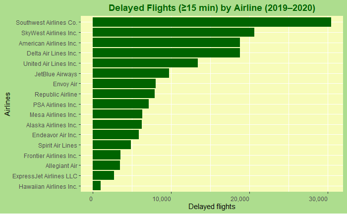

```r
df_delay <- clean_airlines %>%
  group_by(carrier_name) %>%
  summarise(delayed_flights = sum(arr_del15, na.rm = TRUE), .groups = "drop")

ggplot(df_delay,
       aes(x = reorder(carrier_name, delayed_flights),
           y = delayed_flights)) +
  geom_col(fill = "darkgreen", color = NA) +
  labs(title = "Delayed Flights (≥15 min) by Airline (2019–2020)",
       x = "Airlines",
       y = "Delayed flights") +
  scale_y_continuous(labels = scales::label_comma()) +
  theme(
    axis.text.x = element_text(vjust = 0.5, hjust = 1),
    legend.position = "right",
    plot.title = element_text(face = "bold", color = "darkgreen", hjust = 0.5),
    panel.background = element_rect(fill = "#f7fcb9", colour = NA),
    plot.background  = element_rect(fill = "#addd8e", colour = NA)
  )+
  coord_flip()
```

## Delayed Flights by State (2019)

The U.S. map shades each state according to the total number of flights delayed more than 15 minutes. Darker colors represent more delays, and the results align with the table: California, Texas, and Florida stand out as the states with the greatest number of delays.

When these results are compared with the earlier table of most-visited states, shows a clear pattern: states with more recorded flights, such as California, Texas, and Florida, also tend to have more delays. Likewise, states with relatively few flights in this data set, including Wyoming, West Virginia, and Vermont, show the fewest delays.

```r
#2019 subset for graphing
subset_map <- clean_airlines %>%
  filter(year == 2019) %>%
  group_by(abbr) %>%
  summarise(carrier_sum = sum(arr_del15, na.rm = TRUE), .groups = "drop") %>%
  arrange(carrier_sum)

subset_map
```

| abbr | carrier_sum |
| --- | --- |
| WY | 109 |
| WV | 119 |
| NH | 167 |
| VT | 200 |
| KS | 230 |
| ME | 250 |
| SD | 261 |
| MT | 263 |
| MS | 277 |
| ND | 293 |

[output cut: 40 more lines]

```r
NA
```

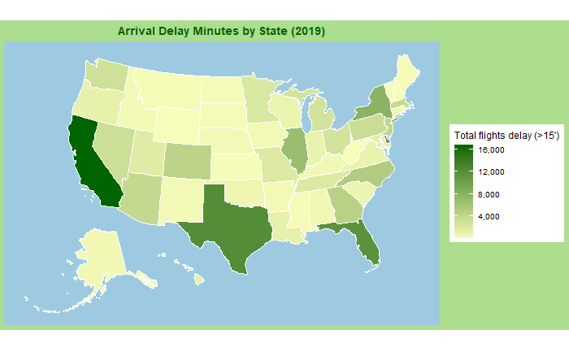

```r
map_df <- subset_map %>%
  mutate(abbr = toupper(abbr)) %>%
  filter(abbr %in% state.abb) %>%                             # drop territories
  inner_join(usmap::fips_info() %>% select(abbr, fips), by = "abbr") %>%
  transmute(fips, value = carrier_sum)


plot_usmap(data = map_df, values = "value", color = "white") +
  scale_fill_continuous(low = "#f7fcb9", high = "darkgreen",
                        name = "Total flights delay (>15')",
                        labels = scales::comma) +
  labs(title = "Arrival Delay Minutes by State (2019)") +
  theme(
    legend.position = "right",
    plot.title = element_text(face = "bold", color = "darkgreen", hjust = 0.5),
    panel.background = element_rect(fill = "#9ecae1", colour = NA),
    plot.background  = element_rect(fill = "#addd8e", colour = NA)
  )
```

## Delayed Flights by State (2020)

In 2020, Vermont recorded the fewest flights delayed by more than 15 minutes, while Texas recorded the most. Compared with 2019, the overall volume of data per state is much lower, reflecting a substantial reduction in flight activity during 2020. For instance, the state with the fewest delayed flights in 2020 had only 26 records, whereas the minimum in 2019 was 109. Similarly, Texas, this year’s top state, had 6,552 delayed flights, compared with California’s 16,861 delayed flights in 2019.

```r
#2020 subset for graph
subset2 <- clean_airlines %>%
  filter(year == 2020) %>%
  group_by(abbr) %>%
  summarize(carrier_sum = sum(arr_del15))


arrange(subset2, carrier_sum)
```

| abbr | carrier_sum |
| --- | --- |
| VT | 26 |
| WV | 28 |
| NH | 39 |
| RI | 63 |
| MS | 67 |
| ME | 78 |
| KS | 114 |
| NM | 138 |
| SD | 140 |
| WY | 141 |

[output cut: 40 more lines]

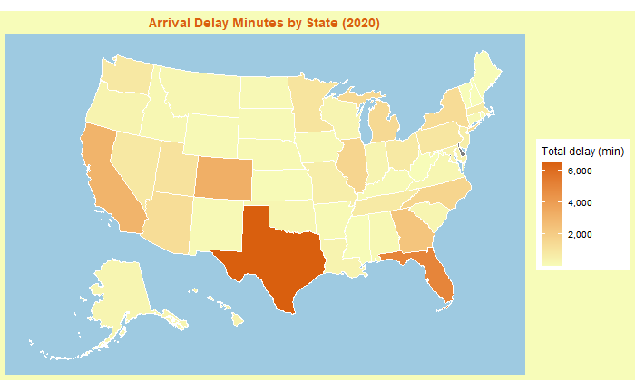

```r
map_df_2020 <- subset2 %>%
  mutate(abbr = toupper(abbr)) %>%
  filter(abbr %in% state.abb) %>%
  inner_join(usmap::fips_info() %>% select(abbr, fips), by = "abbr") %>%
  transmute(fips, value = carrier_sum)



plot_usmap(data = map_df_2020, values = "value", color = "white") +
  scale_fill_continuous(low = "#f7fcb9", high = "#d95f0e",
                        name = "Total delay (min)",
                        labels = scales::comma) +
  labs(title = "Arrival Delay Minutes by State (2020)") +
  theme(
    legend.position = "right",
    plot.title = element_text(face = "bold", color = "#d95f0e", hjust = 0.5),
    panel.background = element_rect(fill = "#9ecae1", colour = NA),
    plot.background  = element_rect(fill = "#f7fcb9", colour = NA)
  )
```

## West Virginia — Causes of Delays

Given our earlier findings, it is useful to look more closely at West Virginia’s delay patterns. This state consistently appears among those with the fewest flights overall and the lowest number of delays longer than 15 minutes. Here, delay minutes are measured as the number of minutes past the scheduled time of departure.

```r
#prepare and filter WV data
WVdata <- clean_airlines %>%
  filter(abbr == "WV") %>%
  summarize(
    WVcarr_sum = sum(carrier_delay),
    WVwea_sum = sum(weather_delay),
    WVnas_sum = sum(nas_delay),
    WVsec_sum = sum(security_delay),
    WVairc_sum = sum(late_aircraft_delay)
  )
```

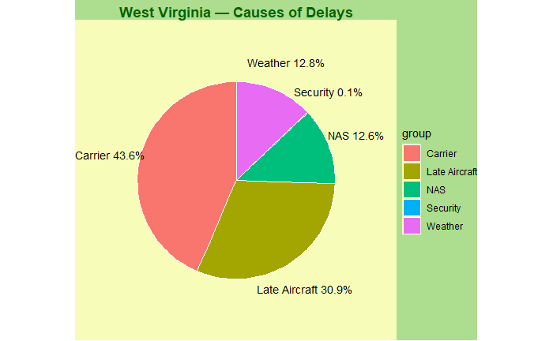

```r
pieWV <- WVdata %>%
  pivot_longer(everything(), names_to = "group", values_to = "value") %>%
  mutate(
    group = recode(
      group,
      WVcarr_sum = "Carrier",
      WVwea_sum  = "Weather",
      WVnas_sum  = "NAS",
      WVsec_sum  = "Security",
      WVairc_sum = "Late Aircraft"
    )
  ) %>%
  mutate(
    pct   = value / sum(value),
    label = paste0(group, " ", scales::percent(pct, accuracy = 0.1))
  ) %>%
  arrange(desc(group)) %>%                       # just to fix order
  mutate(ypos = cumsum(pct) - 0.5 * pct)        # slice midpoints

ggplot(pieWV, aes(x = 1, y = pct, fill = group)) +
  geom_col(width = 1, color = "white") +
  coord_polar(theta = "y") +
  # labels slightly outside the pie
  geom_text(aes(x = 1.8, y = ypos, label = label),
            size = 3.8) +
  theme_void() +
  labs(title = "West Virginia — Causes of Delays") +
  theme(
    legend.position = "right",                    # remove legend
    plot.title = element_text(face = "bold", color = "darkgreen", hjust = 0.5),
    panel.background = element_rect(fill = "#f7fcb9", colour = NA),
    plot.background  = element_rect(fill = "#addd8e", colour = NA)
  )
```

### West Virginia Airlines Analysis

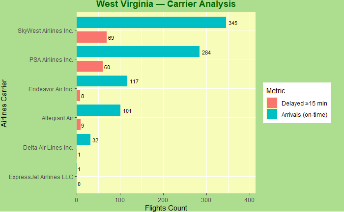

```r
WVairlines <- clean_airlines %>%
  filter(abbr == "WV") %>%
  group_by(carrier_name) %>%
  summarise(
    arr_flights = sum(arr_flights, na.rm = TRUE),
    arr_del15   = sum(arr_del15,   na.rm = TRUE),
    .groups = "drop"
  )

WVlong <- WVairlines %>%
  pivot_longer(
    cols = c(arr_flights, arr_del15),
    names_to = "Metric",
    values_to = "value"
  ) %>%
  mutate(carrier_name = reorder(carrier_name, value, FUN = sum))


ggplot(WVlong, aes(x = carrier_name, y = value, fill = Metric)) +
  geom_col(position = position_dodge(width = 1), width = 0.75) +
  geom_text(
    aes(label = scales::comma(value)),
    position = position_dodge(width = 1),
    hjust = -0.3,
    nudge_y = 8,
    size = 3
  ) +
  scale_y_continuous(
    labels = scales::comma,
    expand = expansion(mult = c(0, 0.20))
  ) +
  labs(title = "West Virginia — Carrier Analysis",
       x = "Airlines Carrier",
       y = "Flights Count") +
  theme(
    legend.position = "right",
    plot.title = element_text(face = "bold", color = "darkgreen", hjust = 0.5),
    panel.background = element_rect(fill = "#f7fcb9", colour = NA),
    plot.background  = element_rect(fill = "#addd8e", colour = NA),
    plot.margin = margin(r = 20)
  ) +
  scale_fill_discrete(labels = c(arr_del15 = "Delayed ≥15 min",
                                 arr_flights = "Arrivals (on-time)")) +
  coord_flip(clip = "off")
```

## California — Causes of Delays

As with West Virginia, it is useful to look more closely at California, which appears repeatedly in this analysis as one of the states with both the highest traffic and the highest number of delays.

The following pie chart shows the distribution of delay minutes by cause for California in 2019–2020. The largest share of delay minutes comes from late-arriving aircraft (35.7%), which can create a chain reaction of delays at busy airports. Carrier-related problems, such as maintenance, crew issues, or schedule disruptions, account for another 32.2% of delay minutes. NAS-related causes contribute 28.9%, while weather (3.0%) and security (0.2%) make up only a small portion of the total. Taken together, late aircraft and carrier causes represent more than two-thirds of all delay minutes, suggesting that operational factors inside airlines and their networks play a larger role than external conditions in California.

```r
CAdata <- clean_airlines %>%
  filter(abbr == "CA") %>%
  summarize(
    CAcarr_sum = sum(carrier_delay),
    CAwea_sum = sum(weather_delay),
    CAnas_sum = sum(nas_delay),
    CAsec_sum = sum(security_delay),
    CAairc_sum = sum(late_aircraft_delay)

  )
```

```r
pieCA <- CAdata %>%
  pivot_longer(everything(), names_to = "group", values_to = "value")
```

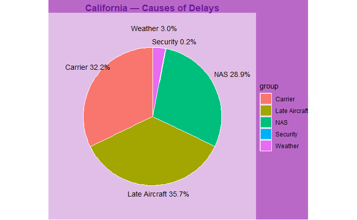

```r
pieCA <- pieCA %>%
  mutate(
    group = recode(
      group,
      CAcarr_sum = "Carrier",
      CAwea_sum  = "Weather",
      CAnas_sum  = "NAS",
      CAsec_sum  = "Security",
      CAairc_sum = "Late Aircraft"
    ),
    pct   = value / sum(value),
    label = paste0(group, " ", scales::percent(pct, accuracy = 0.1))
  ) %>%
  arrange(desc(group)) %>%
  mutate(ypos = cumsum(pct) - 0.5 * pct)

ggplot(pieCA, aes(x = 1, y = pct, fill = group)) +
  geom_col(width = 1, color = "white") +
  coord_polar(theta = "y") +
  geom_text_repel(
    aes(x = 1.7, y = ypos, label = label),
    size = 3.8,
    show.legend = FALSE,
    nudge_x = 0,
    segment.size = 0.1
  ) +
  theme_void() +
  labs(title = "California — Causes of Delays") +
  theme(
    legend.position = "right",
    plot.title = element_text(face = "bold", color = "#6A1B9A", hjust = 0.5),
    panel.background = element_rect(fill = "#E1BEE7", colour = NA),
    plot.background  = element_rect(fill = "#BA68C8", colour = NA)
  )
```

### California Airlines Analysis

The bar chart compares the number of on-time flights and flights delayed by at least 15 minutes for major airlines serving California during 2019–2020. Southwest Airlines Co. and SkyWest Airlines Inc. dominate the market in this data set, together accounting for more than half of the recorded flights. Other carriers, including United, American, Delta, Alaska, JetBlue, Spirit, Mesa, and Frontier, also show substantial numbers of both on-time and delayed flights. Overall, the visualization highlights California’s very high traffic volume and suggests that many of its delays are linked to how airlines manage their schedules and fleets, rather than primarily to weather.

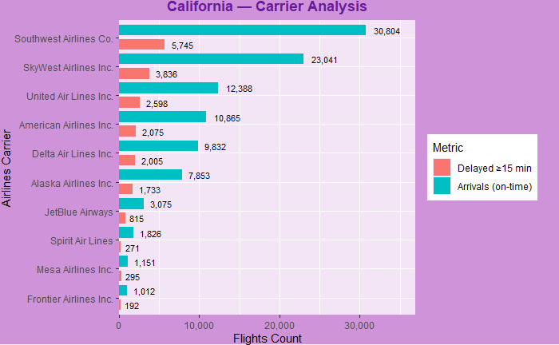

```r
CAairlines <- clean_airlines %>%
  filter(abbr == "CA") %>%
  group_by(carrier_name) %>%
  summarise(
    arr_flights = sum(arr_flights, na.rm = TRUE),
    arr_del15   = sum(arr_del15,   na.rm = TRUE),
    .groups = "drop"
  ) %>%
  mutate(total = arr_flights + arr_del15) %>%
  slice_max(total, n = 10, with_ties = FALSE)



CAlong <- CAairlines %>%
  pivot_longer(
    cols = c(arr_flights, arr_del15),
    names_to = "Metric",
    values_to = "value"
  ) %>%

  mutate(carrier_name = reorder(carrier_name, value, FUN = sum))


ggplot(CAlong, aes(x = carrier_name, y = value, fill = Metric)) +
  geom_col(position = position_dodge(width = 1), width = 0.75) +
  geom_text(
    aes(label = scales::comma(value)),
    position = position_dodge(width = 1),
    hjust = -0.3,
    nudge_y = 8,
    size = 3
  ) +
  scale_y_continuous(
    labels = scales::comma,
    expand = expansion(mult = c(0, 0.20))
  ) +
  labs(title = "California — Carrier Analysis",
       x = "Airlines Carrier",
       y = "Flights Count") +
  theme(
    legend.position = "right",
    plot.title = element_text(face = "bold", color = "#6A1B9A", hjust = 0.5),
    panel.background = element_rect(fill = "#F3E5F5", colour = NA),
    plot.background  = element_rect(fill = "#CE93D8", colour = NA),
    plot.margin = margin(r = 20)
  ) +
  scale_fill_discrete(labels = c(arr_del15 = "Delayed ≥15 min",
                                 arr_flights = "Arrivals (on-time)")) +
  coord_flip(clip = "off")
```

## Texas — Causes of Delays

Texas stands out in this study because it ranks at the top for flight delays in 2020. The state hosts major aviation hubs such as Dallas–Fort Worth (DFW) and Houston (IAH), which handle large volumes of passengers and freight. With this constant flow of traffic, bottlenecks are common, and occasional severe storms can make those bottlenecks worse.

The following pie chart shows the distribution of delay minutes by cause in Texas for 2019–2020. The largest share of delay time (42.1%) comes from late-arriving aircraft, indicating that many Texas delays start upstream when a previous flight arrives behind schedule. Carrier-related issues, such as maintenance, crew, or scheduling problems, account for another 33.0% of delay minutes. NAS causes contribute 19.9%, while weather explains only 4.9% and security just 0.2% of total delay time. Even though Texas has a pronounced severe-weather season, most delay minutes in this data set are linked to operational and network factors rather than storms.

```r
TXdata <- clean_airlines %>%
  filter(abbr == "TX") %>%
  summarize(
    TXcarr_sum = sum(carrier_delay),
    TXwea_sum = sum(weather_delay),
    TXnas_sum = sum(nas_delay),
    TXsec_sum = sum(security_delay),
    TXairc_sum = sum(late_aircraft_delay)

  )
```

```r
pieTX <- TXdata %>%
  pivot_longer(everything(), names_to = "group", values_to = "value")
```

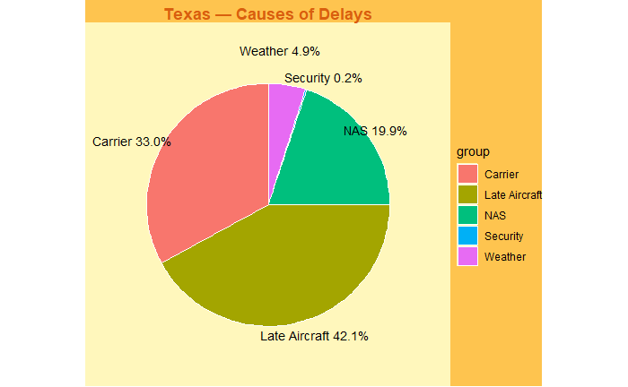

```r
pieTX <- TXdata %>%
  tidyr::pivot_longer(everything(), names_to = "group", values_to = "value") %>%
  filter(!is.na(value)) %>%
  mutate(group = recode(group,
    TXcarr_sum="Carrier",
    TXwea_sum="Weather",
    TXnas_sum="NAS",
    TXsec_sum="Security",
    TXairc_sum="Late Aircraft"),
    pct   = value / sum(value),
    label = paste0(group, " ", scales::percent(pct, accuracy = 0.1))
  ) %>%
  arrange(desc(group)) %>%
  mutate(ypos = cumsum(pct) - 0.5 * pct)

ggplot(pieTX, aes(x = 1, y = pct, fill = group)) +
  geom_col(width = 1, color = "white") +
  coord_polar(theta = "y") +
  geom_text_repel(
    aes(x = 1.7, y = ypos, label = label),
    size = 3.8,
    show.legend = FALSE,
    nudge_x = 0,
    segment.size = 0.1
  ) +
  theme_void() +
  labs(title = "Texas — Causes of Delays") +
  theme(
    legend.position = "right",
    plot.title = element_text(face="bold", color="#d95f0e", hjust=0.5),
    panel.background = element_rect(fill="#fff7bc", colour=NA),
    plot.background  = element_rect(fill="#fec44f", colour=NA)
  )
```

### Texas Airlines Analysis

The carrier analysis bar chart compares on-time flights and delays of at least 15 minutes for the major airlines serving Texas. American Airlines, Southwest, Envoy, and Mesa together operate the majority of flights in this state. Smaller or low-cost carriers (such as Spirit, ExpressJet, and Republic) run fewer flights overall but still register noticeable numbers of delays. Taken together, these results emphasize that high traffic volumes at Texas hubs, combined with late aircraft and carrier-related issues, are central drivers of the state’s delay patterns.

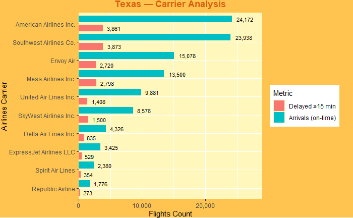

```r
TXairlines <- clean_airlines %>%
  filter(abbr == "TX") %>%
  group_by(carrier_name) %>%
  summarise(
    arr_flights = sum(arr_flights, na.rm = TRUE),
    arr_del15   = sum(arr_del15,   na.rm = TRUE),
    .groups = "drop"
  ) %>%
  mutate(total = arr_flights + arr_del15) %>%
  slice_max(total, n = 10, with_ties = FALSE)



TXlong <- TXairlines %>%
  pivot_longer(
    cols = c(arr_flights, arr_del15),
    names_to = "Metric",
    values_to = "value"
  ) %>%

  mutate(carrier_name = reorder(carrier_name, value, FUN = sum))


ggplot(TXlong, aes(x = carrier_name, y = value, fill = Metric)) +
  geom_col(position = position_dodge(width = 1), width = 0.75) +
  geom_text(
    aes(label = scales::comma(value)),
    position = position_dodge(width = 1),
    hjust = -0.3,
    nudge_y = 8,
    size = 3
  ) +
  scale_y_continuous(
    labels = scales::comma,
    expand = expansion(mult = c(0, 0.20))
  ) +
  labs(title = "Texas — Carrier Analysis",
       x = "Airlines Carrier",
       y = "Flights Count") +
  theme(
    legend.position = "right",
    plot.title = element_text(face="bold", color="#d95f0e", hjust=0.5),
    panel.background = element_rect(fill="#fff7bc", colour=NA),
    plot.background  = element_rect(fill="#fec44f", colour=NA),
    plot.margin = margin(r = 20)
  ) +
  scale_fill_discrete(labels = c(arr_del15 = "Delayed ≥15 min",
                                 arr_flights = "Arrivals (on-time)")) +
  coord_flip(clip = "off")
```

## Results

This analysis used grouped summary statistics and a series of visualizations, circle packing plots, bar charts, U.S. maps, and comparative boxplots, to examine how flight delays vary by airline, state, and cause in 2019–2020. Grouping the data by airline and state made it possible to compare traffic volume and delay counts side by side, while maps and boxplots highlighted geographic patterns and the distribution of delay minutes (including outliers) across locations. Cause-of-delay pie charts for selected states (West Virginia, California, Texas) were used to break total delay minutes into NAS, weather, carrier, late aircraft, and security categories. These methods were chosen because they provide visual comparisons of both scale, like how many flights/delays are there in minutes.

At the state level, the boxplots show a clear gap between the states with the most and least total delay minutes. Among the top-delay states, places with large hub airports such as New Jersey, Massachusetts, and DC have much higher medians and very wide spreads on the log scale, indicating that their airports accumulate more total delay time and that delays are highly variable within those states. In contrast, the bottom-delay states, like West Virginia, Maine, Mississippi, and Vermont have much lower medians and tighter ranges, which would suggest that delay totals are substantially smaller. Another finding suggests that traffic volume and hub status are important drivers of delay but not the only ones; even lower-traffic states can occasionally experience very high total delays at specific airports, while some airports in high-delay states perform relatively better.

## Conclusions

Overall, the analysis suggests that both systemic and operator-specific factors shape U.S. flight delays. States and hubs with heavy traffic naturally accumulate more delayed flights, but the composition of delay causes points toward airline-controlled factors, late aircraft, and carrier operations as the dominant contributors to total delay minutes in this sample. High-volume carriers can differ substantially in how often their flights are delayed, implying that schedule design, turn times, crew management, and fleet utilization all play important roles alongside NAS capacity and weather.

There are, however, several limitations. The data set is a refined subset of the full Department of Transportation records, so the results represent this sample rather than the entire U.S. network. Aggregating delays at the state level hides differences between specific airports within the same state and causes categories to rely on how airlines report delay reasons, which may introduce reporting bias. The project is also descriptive: it identifies patterns and associations but does not estimate causal effects. Future work could extend this analysis by using larger, more complete data sets, the use of probabilities or time series methods.

## References

[Kaggle CVS](https://www.kaggle.com/datasets/eugeniyosetrov/airline-delays) [Bureau of Transportation Statistics Website](https://www.transtats.bts.gov/OT_Delay/OT_DelayCause1.asp?20=E)

ASPMHelp. (n.d.). Definitions of variables – Delay NAS causes; Types of delay.

[Federal Aviation Administration](https://www.aspm.faa.gov/aspmhelp/index/ASQP__Definitions_of_Variables.html)

Airports Council International (ACI) World. [“The Top 10 Busiest Airports in the World Revealed.” 11 Apr. 2022.](https://aci.aero/2022/04/11/the-top-10-busiest-airports-in-the-world-revealed/)